# Medicare Part D 2017_analysis

Darya Akimova

7/8/2019

# Setup

## Introduction:

Medicare Part D Drug Spending:

- Medicare generally available for people age 65 or older, but younger people with disabilities or end stage renal disease may qualify
- Part D covers self-administered prescription drugs (Part B covers drugs administered in a clinical setting, like many chemotherapeutics)
- 2017 dataset includes data for years 2013-2017
- Missing values may be truly missing or redacted

Q: Is there a relationship between drug type/class/application and Medicare Part D spending or prescription count?

- No standard database identifiers except for brand name and generic name are provided for drugs in the Part D data - hard to associate drugs with class
- In newer datasets, CMS provides a drug uses summary that may be useful for this purpose

## Packages:

```r
library(tidyverse)
library(data.world)
library(ggthemes)
library(GGally)
library(tidytext)
library(glmnet)
theme_set(theme_minimal())
```

## Data:

```r
### import:
# drug spending variable dictionary
data_source <- "dakimova/medicare-top-drugs-analysis"
data_dict <- data.world::query(
  data.world::qry_sql("SELECT * FROM data_dictionary_4"),
  dataset = data_source
)
# Medicare Part D spending data 2013-2017
spend_by_drug_manu <- data.world::query(
  data.world::qry_sql("SELECT * FROM manufacturer_summary_4"),
  dataset = data_source
)
# Drug use summaries for drugs included in the 2013-2017 spending data
drug_use_info <- data.world::query(
  data.world::qry_sql("SELECT * FROM drug_use_information_4"),
  dataset = data_source
)
### preview:
data_dict
```

```
## # A tibble: 14 x 2
##    variable_name                       description
##    <chr>                               <chr>
##  1 Brand Name                          The name of the drug filled. This i~
##  2 Generic Name                        A term referring to the chemical in~
##  3 Manufacturer                        Name of the manufacturer of the dru~
##  4 Number of Manufacturers             Number of manufacturers for each dr~
##  5 Total Spending                      Aggregate drug spending for the Med~
##  6 Total Dosage Units                  The sum of the dosage units of medi~
##  7 Total Claims                        Number of prescription fills for ea~
##  8 Total Beneficiaries                 Number of Part D beneficiaries util~
##  9 Average Spending Per Dosage Unit (~ Medicare Part D drug spending divid~
## 10 Average Spending Per Claim          Part D drug spending divided by the~
## 11 Average Spending Per Beneficiary    Total Part D drug spending divided ~
## 12 Change in Average Spending Per Dos~ The percent change in average spend~
## 13 Annual Growth Rate in Average Spen~ The constant average change in spen~
## 14 Note: Blanks indicate the data are~ <NA>
```

```r
dim(spend_by_drug_manu)
```

```
## [1] 7216   40
```

```r
colnames(spend_by_drug_manu)
```

```
##  [1] "brand_name"
##  [2] "generic_name"
##  [3] "manufacturer"
##  [4] "total_spending"
##  [5] "total_dosage_units"
##  [6] "total_claims"
##  [7] "total_beneficiaries"
##  [8] "average_spending_per_dosage_unit_weighted"
##  [9] "average_spending_per_claim"
## [10] "average_spending_per_beneficiary"
## [11] "total_spending_2"
## [12] "total_dosage_units_2"
## [13] "total_claims_2"
## [14] "total_beneficiaries_2"
## [15] "average_spending_per_dosage_unit_weighted_2"
```

[output cut: 25 more lines]

```r
spend_by_drug_manu
```

```
## # A tibble: 7,216 x 40
##    brand_name generic_name manufacturer total_spending total_dosage_un~
##    <chr>      <chr>        <chr>                 <dbl>            <dbl>
##  1 1st Tier ~ Pen Needle,~ Owen Mumfor~         94538.           518920
##  2 1st Tier ~ Pen Needle,~ Owen Mumfor~            NA                NA
##  3 Abacavir   Abacavir Su~ Apotex Corp        4492742.           628513
##  4 Abacavir   Abacavir Su~ Aurobindo P~       3559815.           495218
##  5 Abacavir   Abacavir Su~ Camber Phar~            NA                NA
##  6 Abacavir   Abacavir Su~ Mylan             18776294.          2624085
##  7 Abacavir-~ Abacavir Su~ Prasco Labs             NA                NA
##  8 Abacavir-~ Abacavir Su~ Teva USA                NA                NA
##  9 Abacavir-~ Abacavir/La~ Lupin Pharm~         78230.             3473
## 10 Abelcet    Amphoterici~ Sigma-Tau/L~        582003.            56574
## # ... with 7,206 more rows, and 35 more variables: total_claims <dbl>,
## #   total_beneficiaries <dbl>,
## #   average_spending_per_dosage_unit_weighted <dbl>,
## #   average_spending_per_claim <dbl>,
## #   average_spending_per_beneficiary <dbl>, total_spending_2 <dbl>,
## #   total_dosage_units_2 <dbl>, total_claims_2 <dbl>,
## #   total_beneficiaries_2 <dbl>,
## #   average_spending_per_dosage_unit_weighted_2 <dbl>,
## #   average_spending_per_claim_2 <dbl>,
## #   average_spending_per_beneficiary_2 <dbl>, total_spending_3 <dbl>,
## #   total_dosage_units_3 <dbl>, total_claims_3 <dbl>,
## #   total_beneficiaries_3 <dbl>,
## #   average_spending_per_dosage_unit_weighted_3 <dbl>,
## #   average_spending_per_claim_3 <dbl>,
## #   average_spending_per_beneficiary_3 <dbl>, total_spending_4 <dbl>,
## #   total_dosage_units_4 <dbl>, total_claims_4 <dbl>,
## #   total_beneficiaries_4 <dbl>,
## #   average_spending_per_dosage_unit_weighted_4 <dbl>,
## #   average_spending_per_claim_4 <dbl>,
## #   average_spending_per_beneficiary_4 <dbl>, total_spending_5 <dbl>,
## #   total_dosage_units_5 <dbl>, total_claims_5 <dbl>,
## #   total_beneficiaries_5 <dbl>,
## #   average_spending_per_dosage_unit_weighted_5 <dbl>,
## #   average_spending_per_claim_5 <dbl>,
## #   average_spending_per_beneficiary_5 <dbl>,
## #   change_in_average_spending_per_dosage_unit_2016_2017 <dbl>,
## #   annual_growth_rate_in_average_spending_per_dosage_unit_2013_2017 <dbl>
```

```r
dim(drug_use_info)
```

```
## [1] 2879    3
```

```r
colnames(drug_use_info)
```

```
## [1] "brand_name"   "generic_name" "drug_uses"
```

```r
drug_use_info
```

```
## # A tibble: 2,879 x 3
##    brand_name         generic_name        drug_uses
##    <chr>              <chr>               <chr>
##  1 1st Tier Unifine ~ Pen Needle, Diabet~ Drug uses not available
##  2 1st Tier Unifine ~ Pen Needle, Diabet~ Drug uses not available
##  3 Abacavir           Abacavir Sulfate    This drug is used with other HIV~
##  4 Abacavir-Lamivudi~ Abacavir Sulfate/L~ This product contains 2 drugs: a~
##  5 Abacavir-Lamivudi~ Abacavir/Lamivudin~ This product contains 3 drugs: a~
##  6 Abelcet            Amphotericin B Lip~ This medication is used to treat~
##  7 Abilify            Aripiprazole        Aripiprazole is used to treat ce~
##  8 Accuretic          Quinapril/Hydrochl~ "This product is used to treat h~
##  9 Acebutolol HCl     Acebutolol HCl      Acebutolol is used to treat high~
## 10 Acetamin-Caff-Dih~ Acetaminophen/Caff~ See also Warning section. This c~
## # ... with 2,869 more rows
```

To Do:

- Spending df needs to be tidied from wide format to long so that each variable is one column
- Drug and manufacturer name cleanup - convert to lowercase
- For drug use df - also convert to lowercase, tokenize drug uses
- Explore drug spending data

# Analysis

## Exploration

```r
### Q: any drugs in spending df not in drug use df?
spend_by_drug_manu %>%
  anti_join(drug_use_info, by = c("brand_name", "generic_name")) %>%
  nrow()
```

```
## [1] 0
```

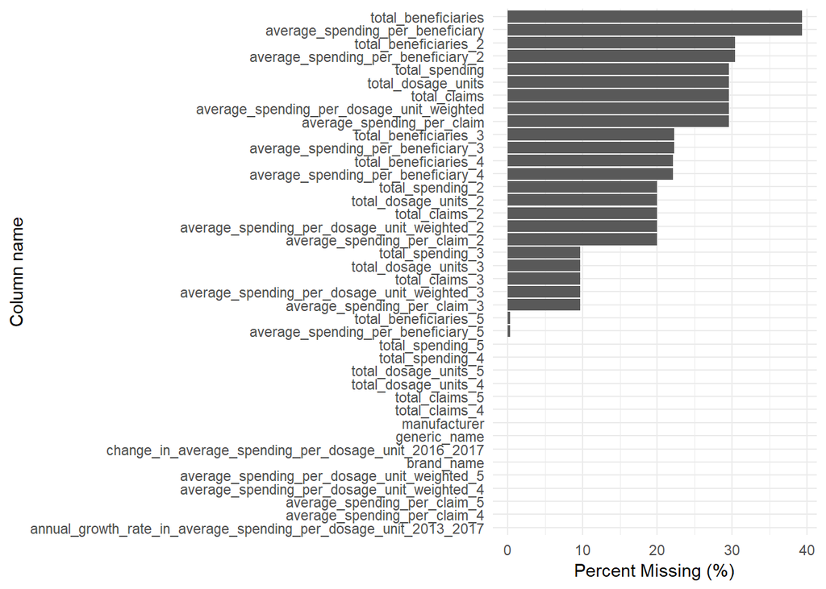

```r
### Q: what is the percent of missing values per column?
spend_by_drug_manu %>%
  sapply(is.na) %>%
  data.frame() %>%
  sapply(sum) %>%
  data.frame() %>%
  rownames_to_column("column") %>%
  rename("num_missing" = ".") %>%
  mutate(
    per_missing = (num_missing / nrow(spend_by_drug_manu)) * 100,
    column = fct_reorder(column, per_missing)
    ) %>%
  ggplot(aes(column, per_missing)) +
  geom_col() +
  coord_flip() +
  ylab("Percent Missing (%)") +
  xlab("Column name")
```

- All drugs in the spending data have a match in the drug use df, but some drugs do not have a summary available.
- 2016 and 2017 data (variables ending in `_4` or `_5`) have few to no missing values, but some of the 2013 and 2014 data have ~ 30-40% missing values (Data could be redacted, or more manufacturers added over the years?)

Q: What are the distributions of the provided summary numeric variables?

```r
data_dict$description[12]
```

```
## [1] "The percent change in average spending per dosage unit from the prior year."
```

```r
### % change in spending per dosage unit 2016 to 2017 mean and median:
spend_by_drug_manu %>%
  summarize(
    mean_change = mean(change_in_average_spending_per_dosage_unit_2016_2017),
    med_change = median(change_in_average_spending_per_dosage_unit_2016_2017)
  )
```

```
## # A tibble: 1 x 2
##   mean_change med_change
##         <dbl>      <dbl>
## 1      0.0283     0.0115
```

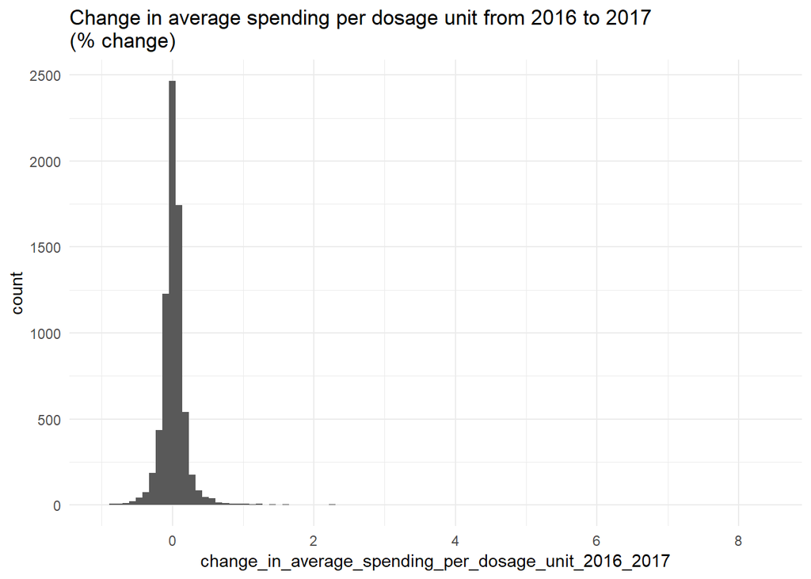

```r
# mean/med close to 0% change
# diff suggests slight right skew, or some high outliers
spend_by_drug_manu %>%
  ggplot(aes(change_in_average_spending_per_dosage_unit_2016_2017)) +
  geom_histogram(bins = 100) +
  ggtitle("Change in average spending per dosage unit from 2016 to 2017\n(% change)")
```

```r
# looks like some high outliers, which drugs are these?:
spend_by_drug_manu %>%
  select(brand_name:manufacturer, change_in_average_spending_per_dosage_unit_2016_2017) %>%
  filter(change_in_average_spending_per_dosage_unit_2016_2017 > 2) %>%
  arrange(change_in_average_spending_per_dosage_unit_2016_2017)
```

```
## # A tibble: 18 x 4
##    brand_name     generic_name      manufacturer  change_in_average_spendi~
##    <chr>          <chr>             <chr>                             <dbl>
##  1 Potassium Chl~ Potassium Chlori~ Qualitest/Pa~                      2.08
##  2 Fluphenazine ~ Fluphenazine HCl  AHP                                2.21
##  3 Sodium Acetate Sodium Acetate    Hospira-Nova~                      2.25
##  4 Cefoxitin      Cefoxitin Sodium  App/Freseniu~                      2.27
##  5 Orbactiv       Oritavancin Diph~ Medicines Co~                      2.38
##  6 Azithromycin*  Azithromycin      Auromedics P~                      2.53
##  7 Gemcitabine H~ Gemcitabine HCl   Accord Healt~                      2.62
##  8 Zosyn          Piperacillin Sod~ Wyeth/Pfizer                       2.63
##  9 Triesence      Triamcinolone Ac~ Alcon/Novart~                      2.72
## 10 Cyclophospham~ Cyclophosphamide  Baxter Healt~                      2.81
## 11 Golytely       PEG3350/Sod Sulf~ Braintree La~                      3.07
## 12 Haloperidol D~ Haloperidol Deca~ Teva Parente~                      3.19
## 13 Rifadin        Rifampin          Sanofi-Avent~                      3.57
## 14 Piperacillin-~ Piperacillin Sod~ App/Premierp~                      3.92
## 15 Magnesium Sul~ Magnesium Sulfat~ Hospira/Pfiz~                      4.43
## 16 Erythrocin La~ Erythromycin Lac~ Hospira/Pfiz~                      7.22
## 17 Oxacillin Sod~ Oxacillin Sodium  Sagent Pharm~                      7.48
## 18 Levulan        Aminolevulinic A~ Dusa/Sun Pha~                      8.34
```

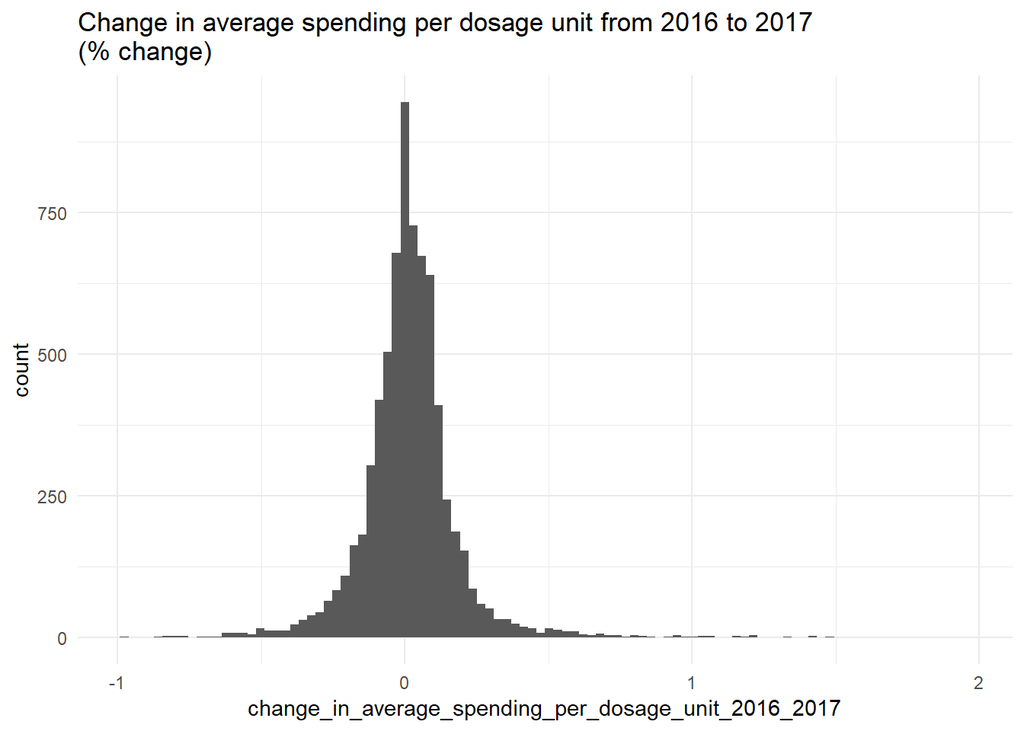

```r
# small number of drugs - filter them out
spend_by_drug_manu %>%
  filter(change_in_average_spending_per_dosage_unit_2016_2017 < 2) %>%
  ggplot(aes(change_in_average_spending_per_dosage_unit_2016_2017)) +
  geom_histogram(bins = 100) +
  ggtitle("Change in average spending per dosage unit from 2016 to 2017\n(% change)")
```

```r
# center close to 0 %, normal dist

### annual change in growth rate in spending per dosage unit from 2013 from 2017
data_dict$description[13]
```

```
## [1] "The constant average change in spending per dosage unit over the most recent five years of data availability, calculated using the compound annual growth rate (CAGR)."
```

```r
spend_by_drug_manu %>%
  summarize(
    mean_change = mean(annual_growth_rate_in_average_spending_per_dosage_unit_2013_2017),
    med_change = median(annual_growth_rate_in_average_spending_per_dosage_unit_2013_2017)
  )
```

```
## # A tibble: 1 x 2
##   mean_change med_change
##         <dbl>      <dbl>
## 1     0.00797    -0.0132
```

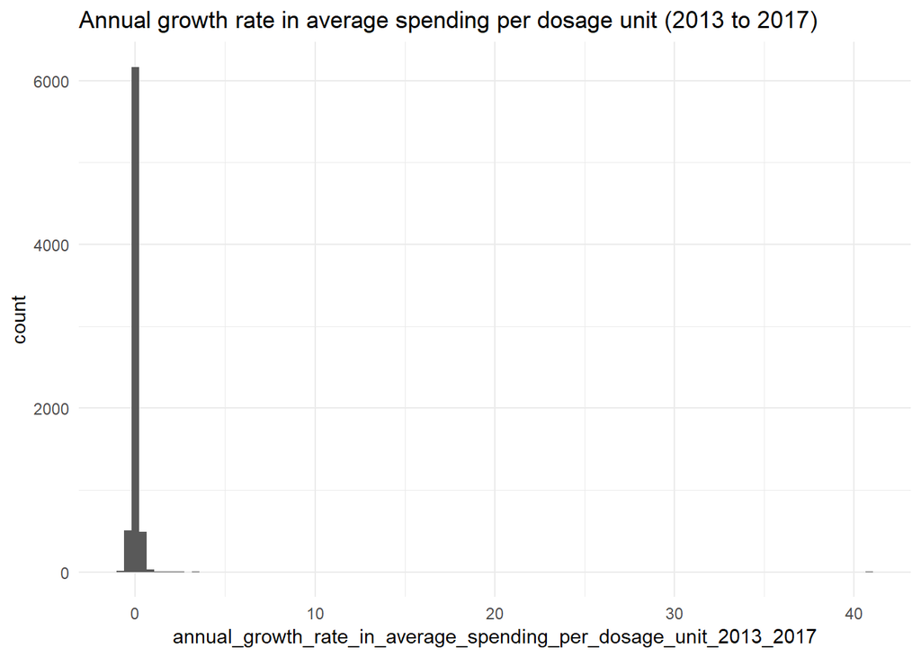

```r
# annual growth rate in spending per dosage unit from 2013 to 2017 also close to zero
spend_by_drug_manu %>%
  ggplot(aes(annual_growth_rate_in_average_spending_per_dosage_unit_2013_2017)) +
  geom_histogram(bins = 100) +
  ggtitle("Annual growth rate in average spending per dosage unit (2013 to 2017)")
```

```r
# outlier point(s):
spend_by_drug_manu %>%
  select(brand_name:manufacturer, annual_growth_rate_in_average_spending_per_dosage_unit_2013_2017) %>%
  filter(annual_growth_rate_in_average_spending_per_dosage_unit_2013_2017 > 10)
```

```
## # A tibble: 1 x 4
##   brand_name generic_name       manufacturer  annual_growth_rate_in_averag~
##   <chr>      <chr>              <chr>                                 <dbl>
## 1 Virt-Nate  Prenatal Vit,Cal ~ Virtus Pharm~                          40.8
```

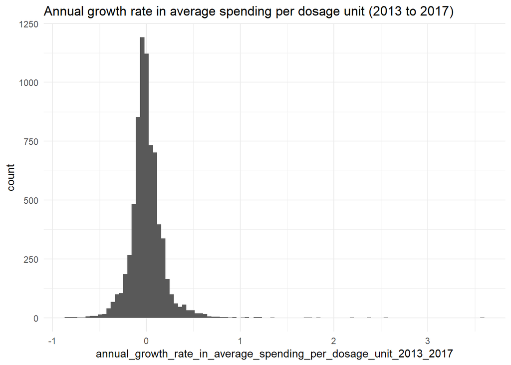

```r
spend_by_drug_manu %>%
  filter(annual_growth_rate_in_average_spending_per_dosage_unit_2013_2017 < 10) %>%
  ggplot(aes(annual_growth_rate_in_average_spending_per_dosage_unit_2013_2017)) +
  geom_histogram(bins = 100) +
  ggtitle("Annual growth rate in average spending per dosage unit (2013 to 2017)")
```

```r
# distribution also somewhat normal
```

It may be interesting to experiment with associating drug uses with these two summary variables for change in spending, but they’re processed and, especially for the annual growth rate from 2013-2017, it’s not entirely clear to me how it was derived from the data.

What about the other variables?

```r
spend_colname <- c(colnames(spend_by_drug_manu)[1:3], paste(colnames(spend_by_drug_manu)[4:10], c(rep("2013", 7), rep("2014", 7), rep("2015", 7), rep("2016", 7), rep("2017", 7)), sep = "."))

spend_tidy <- spend_by_drug_manu %>%
  select(-c(change_in_average_spending_per_dosage_unit_2016_2017, annual_growth_rate_in_average_spending_per_dosage_unit_2013_2017)) %>%
  # fix column names:
  `colnames<-`(spend_colname) %>%
  # wide df to long
  gather(key = "variable", value = "value", -c(brand_name:manufacturer)) %>%
  # separate year attached through colnames and variable name
  separate(variable, into = c("variable", "year"), sep = "\\.") %>%
  spread(variable, value) %>%
  # string name cleanup:
  mutate_at(vars(brand_name:manufacturer), str_to_lower) %>%
  # some brand names have "*" mark - related to disclaimer for the drug use information indicating that the use information is a summary and
  # does not provide all information about the product
  mutate(brand_name = str_replace(brand_name, "\\*", "")) %>%
  # reorder rows
  arrange(brand_name, generic_name, manufacturer, year)
# result:
spend_tidy
```

```
## # A tibble: 36,080 x 11
##    brand_name generic_name manufacturer year  average_spendin~
##    <chr>      <chr>        <chr>        <chr>            <dbl>
##  1 1st tier ~ pen needle,~ owen mumfor~ 2013              58.4
##  2 1st tier ~ pen needle,~ owen mumfor~ 2014              59.1
##  3 1st tier ~ pen needle,~ owen mumfor~ 2015              58.7
##  4 1st tier ~ pen needle,~ owen mumfor~ 2016              63.1
##  5 1st tier ~ pen needle,~ owen mumfor~ 2017              72.1
##  6 1st tier ~ pen needle,~ owen mumfor~ 2013              NA
##  7 1st tier ~ pen needle,~ owen mumfor~ 2014              42.0
##  8 1st tier ~ pen needle,~ owen mumfor~ 2015              45.5
##  9 1st tier ~ pen needle,~ owen mumfor~ 2016              58.6
## 10 1st tier ~ pen needle,~ owen mumfor~ 2017              67.4
## # ... with 36,070 more rows, and 6 more variables:
## #   average_spending_per_claim <dbl>,
## #   average_spending_per_dosage_unit_weighted <dbl>,
## #   total_beneficiaries <dbl>, total_claims <dbl>,
## #   total_dosage_units <dbl>, total_spending <dbl>
```

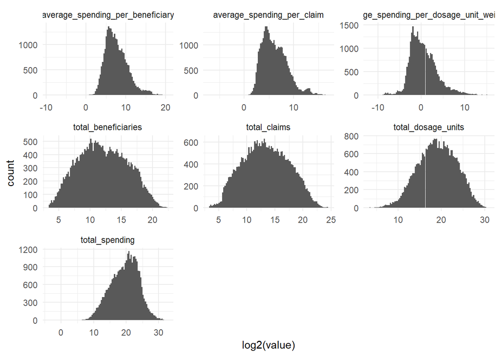

```r
### plots:
# what is the shape of the distribution of the variables
spend_tidy %>%
  gather("variable", "value", -c(brand_name:year)) %>%
  # all of the variable distributions have a strong right skew - take log2
  ggplot(aes(log2(value))) +
  geom_histogram(bins = 100) +
  facet_wrap(~ variable, scales = "free")
```

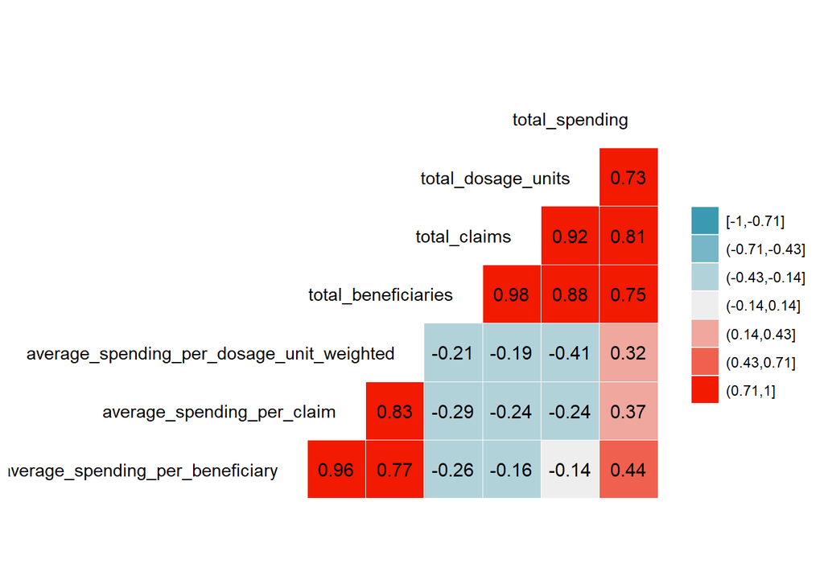

```r
# relathionship between the variables:
spend_tidy %>%
  select(-c(brand_name:year)) %>%
  mutate_all(log2) %>%
  ggcorr(label = TRUE, label_round = 2, nbreaks = 7, layout.exp = 4, hjust = 1)
```

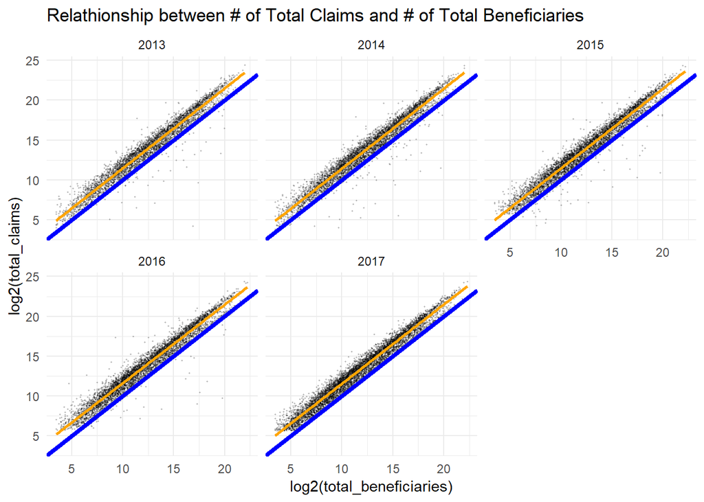

```r
spend_tidy %>%
  ggplot(aes(log2(total_beneficiaries), log2(total_claims))) +
  geom_point(alpha = 0.2, size = 0.2) +
  # unity line in blue
  geom_abline(intercept = 0, slope = 1, color = "blue", size = 1.5) +
  geom_smooth(method = "lm", color = "orange") +
  facet_wrap(~ year) +
  ggtitle("Relathionship between # of Total Claims and # of Total Beneficiaries")
```

```r
# overall, number of claims tends to be larger than the number of befeciaries (possibly indicating that beneficiaries typically get refills)
# what is the approximate number of average refills?
spend_tidy <- spend_tidy %>%
  mutate(num_refill = total_claims / total_beneficiaries)
# average number of refills:
round(mean(spend_tidy$num_refill, na.rm = TRUE), 2)
```

```
## [1] 3.3
```

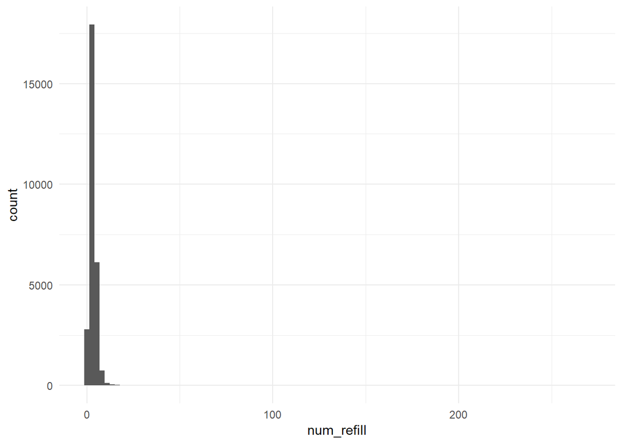

```r
spend_tidy %>%
  ggplot(aes(num_refill)) +
  geom_histogram(bins = 100)
```

```r
# looks like some outliers
spend_tidy %>%
  select(brand_name:year, total_beneficiaries:total_claims, num_refill) %>%
  filter(num_refill > 50)
```

```
## # A tibble: 7 x 7
##   brand_name generic_name manufacturer year  total_beneficia~ total_claims
##   <chr>      <chr>        <chr>        <chr>            <dbl>        <dbl>
## 1 aripipraz~ aripiprazole amneal phar~ 2016               629       169299
## 2 fenofibra~ fenofibrate~ ranbaxy/sun~ 2016                26         3096
## 3 medroxypr~ medroxyprog~ teva usa     2013              2702       215688
## 4 medroxypr~ medroxyprog~ teva usa     2014              2667       244984
## 5 medroxypr~ medroxyprog~ teva usa     2015              2388       208798
## 6 medroxypr~ medroxyprog~ teva usa     2016              2064       180381
## 7 methylphe~ methylpheni~ gavis/lupin  2016                88         6253
## # ... with 1 more variable: num_refill <dbl>
```

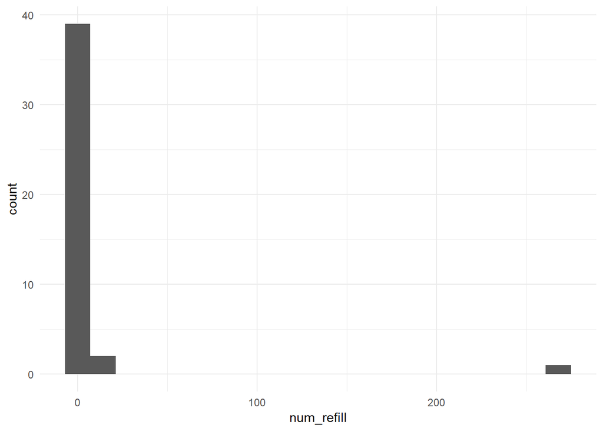

```r
# these are most likely typos
# medroxyprogesterone is also interesting because it's typically used as birth control, but has other uses
spend_tidy %>%
  filter(generic_name == "aripiprazole") %>%
  select(brand_name:year, num_refill) %>%
  ggplot(aes(num_refill)) +
  geom_histogram(bins = 20)
```

```r
# probably typos
```

I’m interested in the connection between drug uses and the most commonly prescribed drugs covered by Medicare Part D. Total spending could also be an intriguing variable to explore, but there are some disclaimers on the CMS.gov website regarding this dataset that raise concerns. Any data relating to cost is based on the gross drug cost, including any Medicare/insurance coverage and beneficiary payments, and CMS is prohibited from disclosing discounts/rebates by the manufacturer.

[cms.gov source](https://www.cms.gov/Research-Statistics-Data-and-Systems/Statistics-Trends-and-Reports/Information-on-Prescription-Drugs/MedicarePartD.html)

## Drug uses summary token analysis

```r
drug_use_cln <- drug_use_info %>%
  mutate_all(str_to_lower) %>%
  # replace "*" next to some brand names - related to disclaimer by CMS that provided drug use info is only a summary
  mutate(brand_name = str_replace(brand_name, "\\*", "")) %>%
  arrange(brand_name, generic_name)
drug_use_cln
```

```
## # A tibble: 2,879 x 3
##    brand_name         generic_name        drug_uses
##    <chr>              <chr>               <chr>
##  1 1st tier unifine ~ pen needle, diabet~ drug uses not available
##  2 1st tier unifine ~ pen needle, diabet~ drug uses not available
##  3 abacavir           abacavir sulfate    this drug is used with other hiv~
##  4 abacavir-lamivudi~ abacavir sulfate/l~ this product contains 2 drugs: a~
##  5 abacavir-lamivudi~ abacavir/lamivudin~ this product contains 3 drugs: a~
##  6 abelcet            amphotericin b lip~ this medication is used to treat~
##  7 abilify            aripiprazole        aripiprazole is used to treat ce~
##  8 abilify maintena   aripiprazole        extended-release aripiprazole in~
##  9 abraxane           paclitaxel protein~ this medication is used to treat~
## 10 absorica           isotretinoin        this medication is used to treat~
## # ... with 2,869 more rows
```

```r
# sanity check to make sure name changes did not alter matches
spend_tidy %>%
  anti_join(drug_use_cln, by = c("brand_name", "generic_name")) %>%
  nrow()
```

```
## [1] 0
```

```r
# how many drugs do not have a use available?
drug_use_cln %>%
  filter(drug_uses == "drug uses not available") %>%
  nrow()
```

```
## [1] 253
```

```r
# 253 items without an associated drug use
set.seed(20)
drug_use_cln %>%
  filter(drug_uses == "drug uses not available") %>%
  sample_n(20)
```

```
## # A tibble: 20 x 3
##    brand_name               generic_name               drug_uses
##    <chr>                    <chr>                      <chr>
##  1 pro comfort alcohol pads alcohol antiseptic pads    drug uses not avail~
##  2 sterile pads             gauze bandage              drug uses not avail~
##  3 ixiaro                   japanese encephalitis vac~ drug uses not avail~
##  4 magellan insulin syringe syringe,needle,insuln,sf ~ drug uses not avail~
##  5 mini ultra-thin ii       pen needle, diabetic       drug uses not avail~
##  6 insulin syringe          syringe w-ndl, disp,insul~ drug uses not avail~
##  7 bd ultra-fine pen needle pen needle, diabetic       drug uses not avail~
##  8 ulticare insulin syringe syring-needl,disp,insul,0~ drug uses not avail~
##  9 sodium phosphate         sod phosphate,monobasic-d~ drug uses not avail~
## 10 comfort ez               syringe and needle,insuli~ drug uses not avail~
## 11 marcaine                 bupivacaine hcl/pf         drug uses not avail~
## 12 clinisol                 parenteral amino acid 15%~ drug uses not avail~
## 13 easy comfort pen needles pen needle, diabetic       drug uses not avail~
## 14 sodium chloride          sodium chloride irrig sol~ drug uses not avail~
## 15 magnebind 400 rx         calcium carb/mag carb/fol~ drug uses not avail~
## 16 ultra comfort            syringe-needle,insulin,0.~ drug uses not avail~
## 17 aldurazyme               laronidase                 drug uses not avail~
## 18 sure comfort             syring-needl,disp,insul,0~ drug uses not avail~
## 19 xylocaine-mpf            lidocaine hcl/pf           drug uses not avail~
## 20 safetyglide insulin syr~ syring-needl,disp,insul,0~ drug uses not avail~
```

```r
# many items missing a drug use are items like syringes, alcohol pads, but some are medications with no provided drug use
drug_uses_token <- drug_use_cln %>%
  filter(drug_uses != "drug uses not available") %>%
  # create unique drug reference key number:
  mutate(drug_num = row_number()) %>%
  unnest_tokens(word, drug_uses) %>%
  distinct() %>%
  # filter out common stop words
  anti_join(stop_words, by = "word")
# result:
drug_uses_token
```

```
## # A tibble: 126,699 x 4
##    brand_name generic_name     drug_num word
##    <chr>      <chr>               <int> <chr>
##  1 abacavir   abacavir sulfate        1 drug
##  2 abacavir   abacavir sulfate        1 hiv
##  3 abacavir   abacavir sulfate        1 medications
##  4 abacavir   abacavir sulfate        1 control
##  5 abacavir   abacavir sulfate        1 infection
##  6 abacavir   abacavir sulfate        1 helps
##  7 abacavir   abacavir sulfate        1 decrease
##  8 abacavir   abacavir sulfate        1 amount
##  9 abacavir   abacavir sulfate        1 body
## 10 abacavir   abacavir sulfate        1 immune
## # ... with 126,689 more rows
```

```r
# how often does each word appear?
token_count <- drug_uses_token %>%
  count(word, sort = TRUE)
token_count
```

```
## # A tibble: 3,878 x 2
##    word            n
##    <chr>       <int>
##  1 advice       2626
##  2 assure       2626
##  3 care         2626
##  4 complete     2626
##  5 effective    2626
##  6 health       2626
##  7 individual   2626
##  8 information  2626
##  9 medical      2626
## 10 note         2626
## # ... with 3,868 more rows
```

```r
# turns out each drug description has the same exact disclaimer at the end, emphasizing that the provided summary does not include all
# of the information about the drug and encourages individuals to see their medical professional for more information
# remove the most common words:
common_words <- drug_uses_token %>%
  count(word) %>%
  filter(n == 2626)
common_words
```

```
## # A tibble: 16 x 2
##    word             n
##    <chr>        <int>
##  1 advice        2626
##  2 assure        2626
##  3 care          2626
##  4 complete      2626
##  5 effective     2626
##  6 health        2626
##  7 individual    2626
##  8 information   2626
##  9 medical       2626
## 10 note          2626
## 11 product       2626
## 12 professional  2626
## 13 safe          2626
## 14 specific      2626
## 15 substitute    2626
## 16 summary       2626
```

```r
nrow(drug_uses_token)
```

```
## [1] 126699
```

```r
drug_uses_token <- drug_uses_token %>%
  filter(!(word %in% common_words$word))
# result:
nrow(drug_uses_token)
```

```
## [1] 84683
```

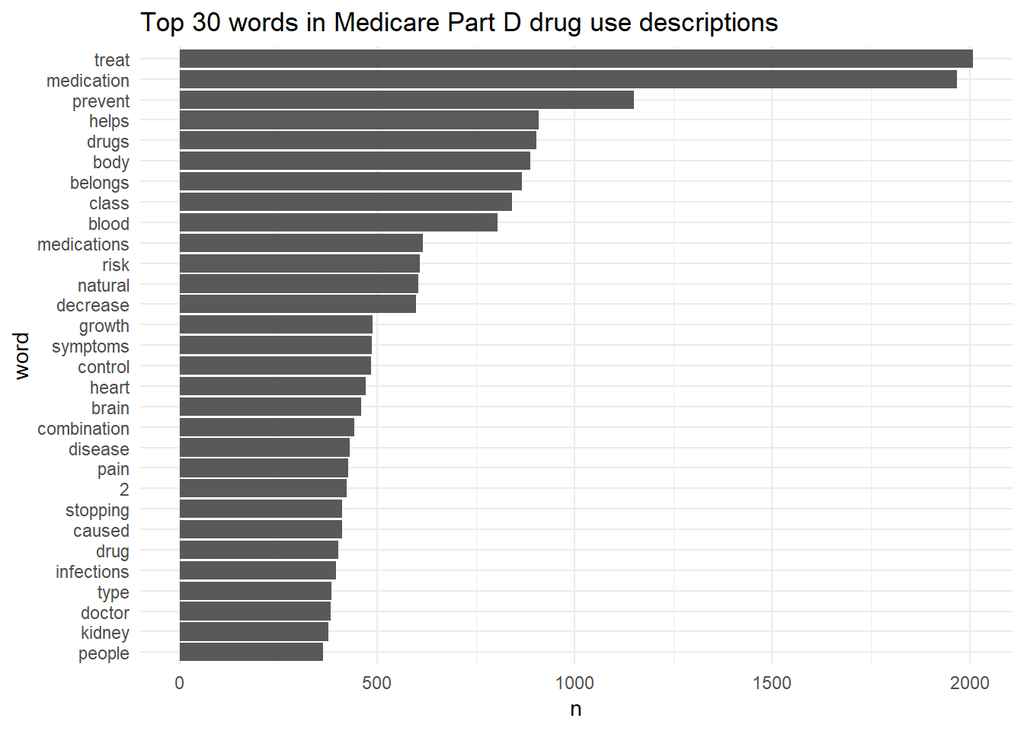

```r
token_count <- token_count %>%
  filter(!(word %in% common_words$word))
token_count %>%
  top_n(30) %>%
  mutate(word = fct_reorder(word, n)) %>%
  ggplot(aes(word, n)) +
  geom_col() +
  coord_flip() +
  ggtitle("Top 30 words in Medicare Part D drug use descriptions")
```

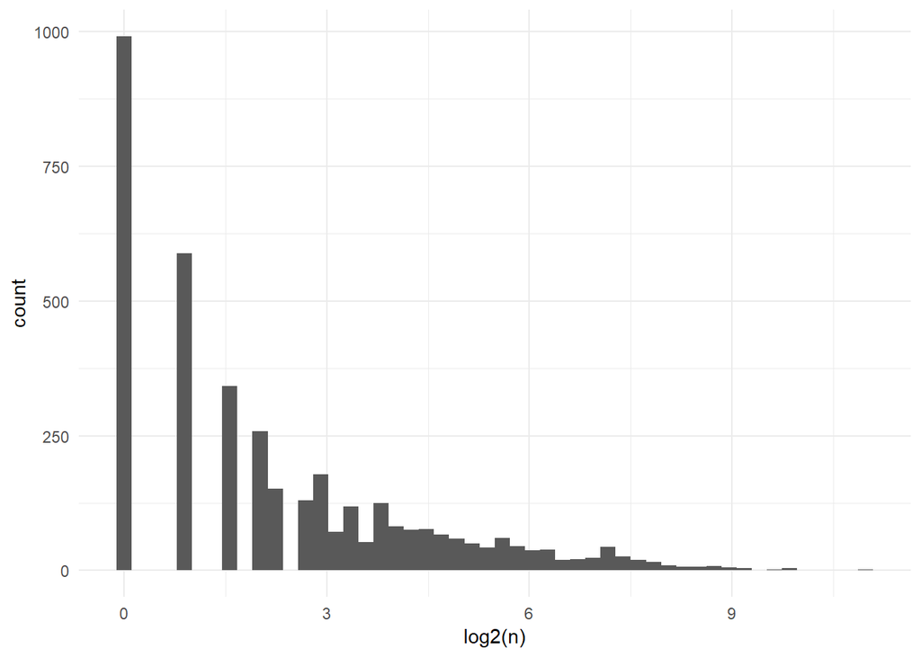

```r
# generic words, but appearance of blood, heart, brain, pain, and kidney potentially interesting

### what is the distribution of counts?
token_count %>%
  ggplot(aes(log2(n))) +
  geom_histogram(bins = 50)
```

```r
# which words have n = 1 counts?
set.seed(20)
token_count %>%
  filter(n == 1) %>%
  sample_n(20)
```

```
## # A tibble: 20 x 2
##    word                       n
##    <chr>                  <int>
##  1 cholangitis                1
##  2 condylomata                1
##  3 swimming                   1
##  4 tbo                        1
##  5 papillary                  1
##  6 rifapentine                1
##  7 sunlight                   1
##  8 methyltetrahydrofolate     1
##  9 praziquantel               1
## 10 slower                     1
## 11 maraviroc                  1
## 12 butabarbital               1
## 13 milnacipran                1
## 14 etravirine                 1
## 15 utis                       1
## 16 oxybate                    1
## 17 membranes                  1
## 18 jittery                    1
## 19 lopinavir                  1
## 20 vardenafil                 1
```

```r
# many rare words are the drug names themselves (drug use info typically references it) and some potentially interesting words,
# but with n = 1 results may be unreliable
token_count_filt <- token_count %>%
  # filter on frequency and at least one letter in the word (remove numbers)
  filter(n >= 10 & str_detect(word, "[a-z]"))
nrow(token_count)
```

```
## [1] 3862
```

```r
nrow(token_count_filt)
```

```
## [1] 1142
```

```r
# over half of unique words removed
drug_token_filt <- drug_uses_token %>%
  filter(word %in% token_count_filt$word)
nrow(drug_uses_token)
```

```
## [1] 84683
```

```r
nrow(drug_token_filt)
```

```
## [1] 76199
```

Now that the drug uses have been tokenized and filtered, the spending data will be modified by calculating the total number of claims over the 5 year dataset period for each drug (by brand and generic), regardless of manufacturer.

Reasons for these decisions:

- This is time series data, but with only 5 data points (one for each year) - would complicate matters
- The Medicare Part D datasets can be unreliable and missing values, redacted data, and even the number of claims can vary from year to year - trying to dig in very deep may be pointless with unreliable data
- Deal with missing data - as long as there is data for at least one year, then no need to try and impute or toss out data (particulary helpful for 2013 where columns had 30-40% missing values)
- Sum over manufacturers because drug should be same across manufacturers and splitting over many manufacturers may distort results

```r
claims_summ <- spend_tidy %>%
  filter(!is.na(total_claims)) %>%
  group_by(brand_name, generic_name) %>%
  # sum total claims over the 5 years:
  summarize(sum_claims = sum(total_claims)) %>%
  ungroup() %>%
  # join drug number from the drug uses set
  inner_join(
    drug_uses_token %>%
      select(brand_name:drug_num) %>%
      distinct(),
    by = c("brand_name", "generic_name")
    )
# result:
claims_summ
```

```
## # A tibble: 2,626 x 4
##    brand_name                 generic_name              sum_claims drug_num
##    <chr>                      <chr>                          <dbl>    <int>
##  1 abacavir                   abacavir sulfate              321012        1
##  2 abacavir-lamivudine        abacavir sulfate/lamivud~      63242        2
##  3 abacavir-lamivudine-zidov~ abacavir/lamivudine/zido~      41688        3
##  4 abelcet                    amphotericin b lipid com~       2189        4
##  5 abilify                    aripiprazole                 7495818        5
##  6 abilify maintena           aripiprazole                  415407        6
##  7 abraxane                   paclitaxel protein-bound        3816        7
##  8 absorica                   isotretinoin                     492        8
##  9 acamprosate calcium        acamprosate calcium           112882        9
## 10 acanya                     clindamycin phos/benzoyl~       3726       10
## # ... with 2,616 more rows
```

```r
nrow(claims_summ)
```

```
## [1] 2626
```

```r
# some drugs could have been filtered out because 1) missing claims data for all 5 years (unlikely) or 2) no drug use available
# number of drugs removed:
spend_by_drug_manu %>% select(brand_name:generic_name) %>% distinct() %>% nrow() - nrow(claims_summ)
```

```
## [1] 253
```

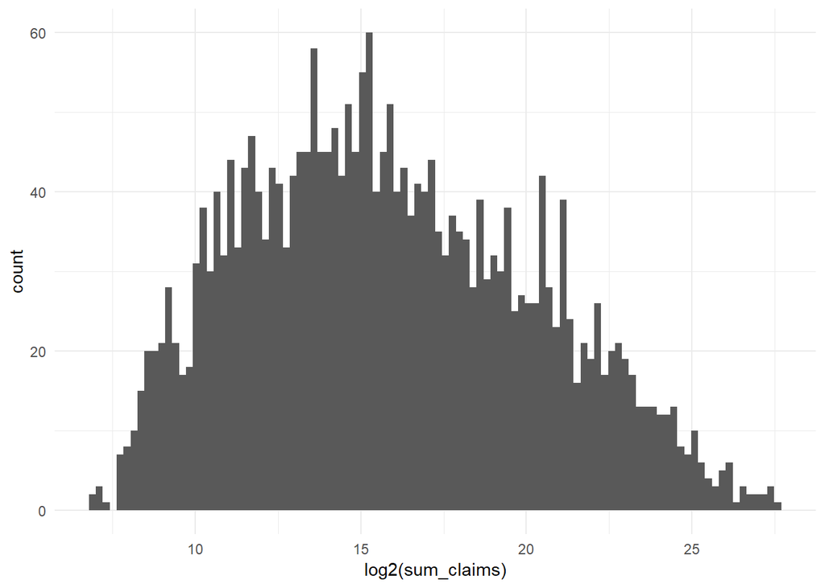

```r
# same number as items with no drug use available
# is the log2 distribution of the sum of total claims normal:
claims_summ %>%
  ggplot(aes(log2(sum_claims))) +
  geom_histogram(bins = 100)
```

```r
claims_summ <- claims_summ %>%
  mutate(sum_claims_log = log2(sum_claims))
```

Regularized regression to tackle the regression task of predicting the number of claims for each drug over a 5-year period based on the drug use tokens.

The benefits of this technique for this problem are:

- Ability to quantitatively predict outcome
- Feature selection to narrow down ~1100 unique words to ones that are associated with the outcome of interest

```r
# create sparse matrix to convert categorical variables (words) to numeric - sparse to manage size
sparse_token_mat <- drug_token_filt %>%
  cast_sparse(drug_num, word)
dim(sparse_token_mat)
```

```
## [1] 2626 1142
```

```r
# outcome:
sum_claims_mat <- as.matrix(claims_summ$sum_claims_log)
# hyperparameter
a_param <- seq(0, 1, by = 0.25)
a_param
```

```
## [1] 0.00 0.25 0.50 0.75 1.00
```

```r
by_brand_models <- a_param %>%
  map(function(x) cv.glmnet(sparse_token_mat, sum_claims_mat, alpha = x, family = "gaussian"))
# result is list, where each model is one element of list:
class(by_brand_models)
```

```
## [1] "list"
```

```r
length(by_brand_models)
```

```
## [1] 5
```

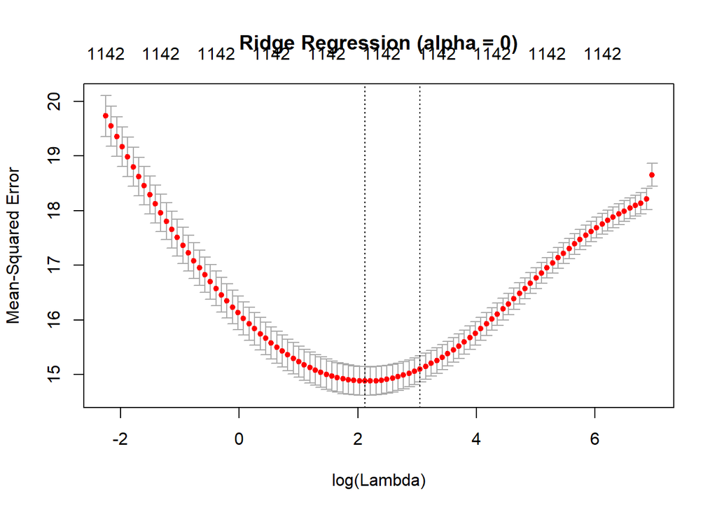

```r
# mean-squared error vs. lambda plots:
plot(by_brand_models[[1]], main = "Ridge Regression (alpha = 0)")
```

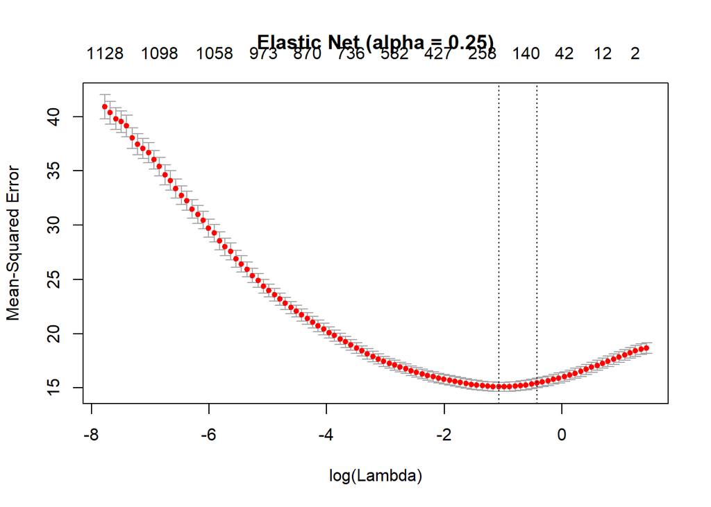

```r
plot(by_brand_models[[2]], main = "Elastic Net (alpha = 0.25)")
```

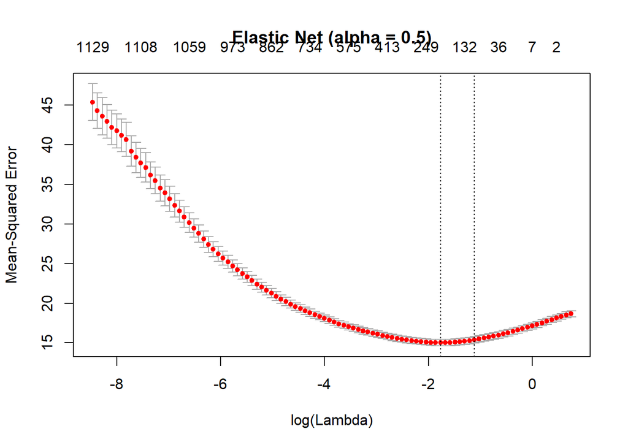

```r
plot(by_brand_models[[3]], main = "Elastic Net (alpha = 0.5)")
```

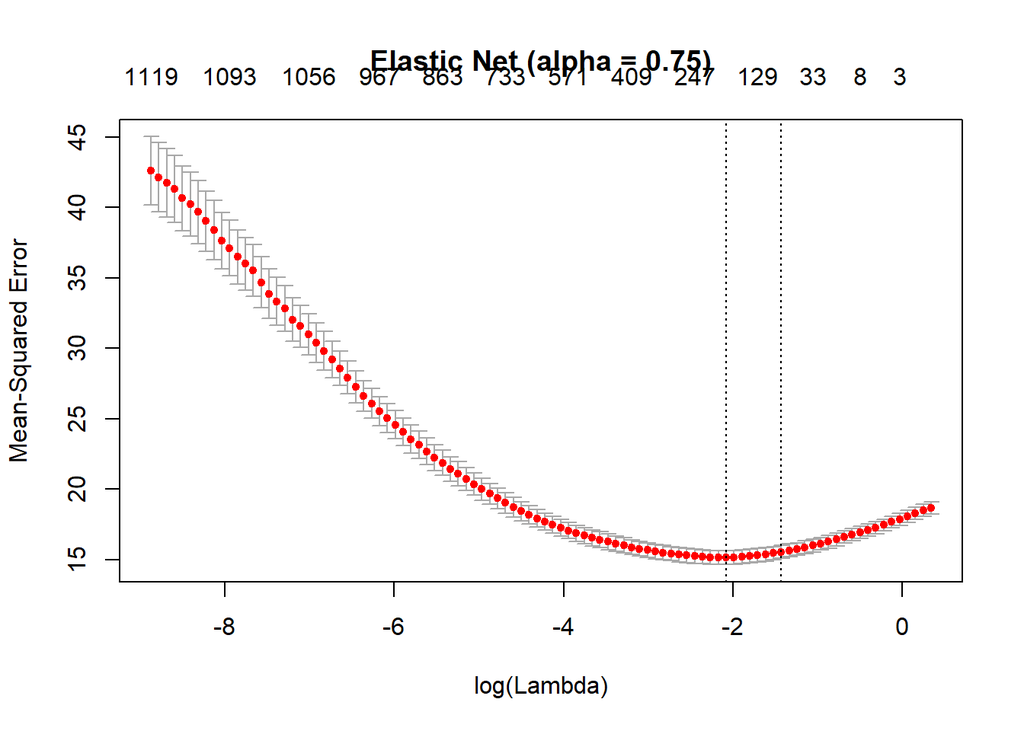

```r
plot(by_brand_models[[4]], main = "Elastic Net (alpha = 0.75)")
```

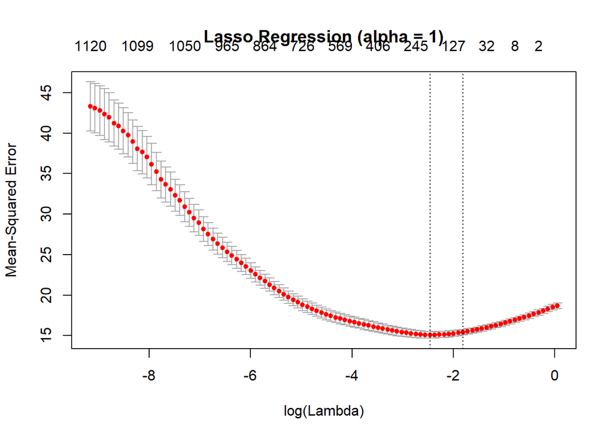

```r
plot(by_brand_models[[5]], main = "Lasso Regression (alpha = 1)")
```

```r
# lambda parameter optimization
by_brand_lambda_min <- map_dbl(by_brand_models, `[[`, "lambda.min")
by_brand_lambda_1se <- map_dbl(by_brand_models, `[[`, "lambda.1se")
# result:
by_brand_lambda_min
```

```
## [1] 8.34002833 0.34145111 0.17072555 0.12491406 0.08536278
```

```r
by_brand_lambda_1se
```

```
## [1] 21.1450117  0.6548726  0.3274363  0.2395740  0.1637181
```

```r
by_brand_models_tidy <- map(by_brand_models, function(x) tidy(x))
# mse for alpha = 0
by_brand_models_tidy[[1]] %>%
  filter(lambda == by_brand_lambda_1se[1])
```

```
## # A tibble: 1 x 6
##   lambda estimate std.error conf.low conf.high nzero
##    <dbl>    <dbl>     <dbl>    <dbl>     <dbl> <int>
## 1   21.1     15.1     0.240     14.9      15.3  1142
```

```r
# mse for alpha = 0.25
by_brand_models_tidy[[2]] %>%
  filter(lambda == by_brand_lambda_1se[2])
```

```
## # A tibble: 1 x 6
##   lambda estimate std.error conf.low conf.high nzero
##    <dbl>    <dbl>     <dbl>    <dbl>     <dbl> <int>
## 1  0.655     15.4     0.440     15.0      15.9   113
```

```r
# mse for alpha = 0.5
by_brand_models_tidy[[3]] %>%
  filter(lambda == by_brand_lambda_1se[3])
```

```
## # A tibble: 1 x 6
##   lambda estimate std.error conf.low conf.high nzero
##    <dbl>    <dbl>     <dbl>    <dbl>     <dbl> <int>
## 1  0.327     15.4     0.403     15.0      15.8   104
```

```r
# mse for alpha = 0.75
by_brand_models_tidy[[4]] %>%
  filter(lambda == by_brand_lambda_1se[4])
```

```
## # A tibble: 1 x 6
##   lambda estimate std.error conf.low conf.high nzero
##    <dbl>    <dbl>     <dbl>    <dbl>     <dbl> <int>
## 1  0.240     15.6     0.459     15.1      16.0    83
```

```r
# mse for alpha = 1
by_brand_models_tidy[[5]] %>%
  filter(lambda == by_brand_lambda_1se[5])
```

```
## # A tibble: 1 x 6
##   lambda estimate std.error conf.low conf.high nzero
##    <dbl>    <dbl>     <dbl>    <dbl>     <dbl> <int>
## 1  0.164     15.4     0.346     15.1      15.8    99
```

```r
by_brand_fin_model <- by_brand_models[[3]]
by_brand_fin_model$lambda.1se
```

```
## [1] 0.3274363
```

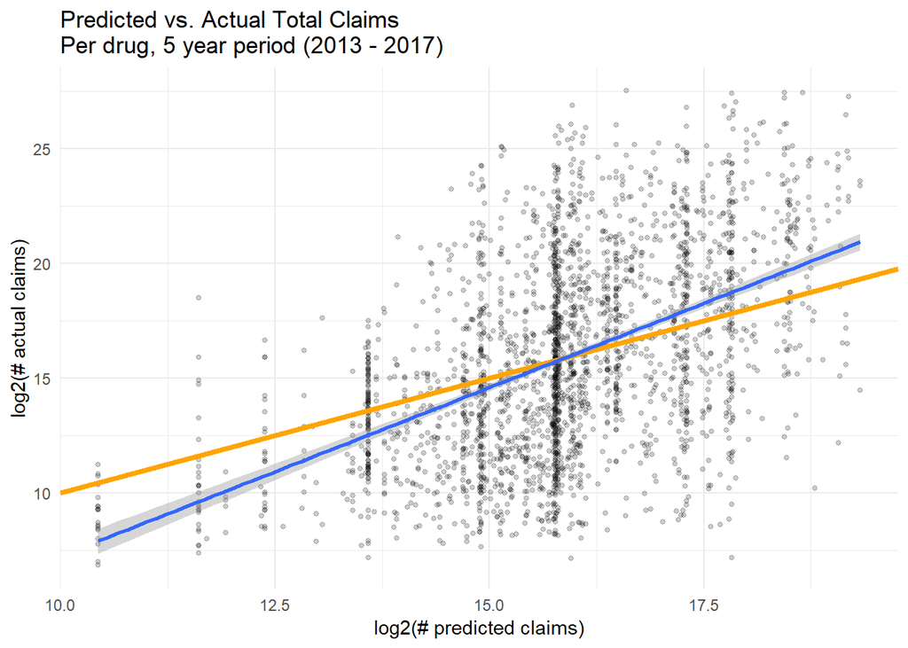

```r
# predictions - mse pretty high
claims_summ$predictions <- predict(by_brand_fin_model, sparse_token_mat)
claims_summ %>%
  ggplot(aes(predictions, sum_claims_log)) +
  geom_point(size = 1, alpha = 0.2) +
  # unity line:
  geom_abline(intercept = 0, slope = 1, color = "orange", size = 1.5) +
  # acutal relationship:
  geom_smooth(method = "lm") +
  xlab("log2(# predicted claims)") +
  ylab("log2(# actual claims)") +
  ggtitle("Predicted vs. Actual Total Claims\nPer drug, 5 year period (2013 - 2017)")
```

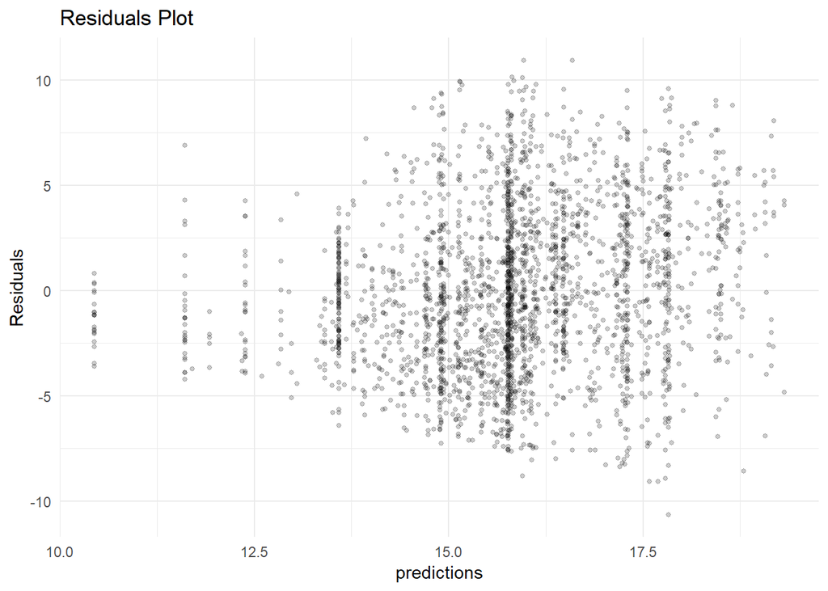

```r
claims_summ <- claims_summ %>%
  mutate(res = sum_claims_log - predictions)
claims_summ %>%
  ggplot(aes(predictions, res)) +
  geom_point(size = 1, alpha = 0.2) +
  ylab("Residuals") +
  ggtitle("Residuals Plot")
```

```r
# root mean squared error:
sqrt(mean(claims_summ$res^2))
```

```
## [1] 3.802968
```

```r
# vs sd:
sd(claims_summ$sum_claims_log)
```

```
## [1] 4.321171
```

```r
# overall, model tends to overestimate lower values of total claims and underestimate higher total claim counts
# pull out words that had non-zero coefficients in the model
by_brand_model_coef <- coef(by_brand_fin_model, by_brand_fin_model$lambda.1se) %>%
  as.matrix() %>%
  as.data.frame() %>%
  rownames_to_column("word") %>%
  as_tibble() %>%
  rename("coef" = `1`) %>%
  filter(coef != 0) %>%
  mutate(abs_coef = abs(coef))
# result:
by_brand_model_coef
```

```
## # A tibble: 105 x 3
##    word            coef abs_coef
##    <chr>          <dbl>    <dbl>
##  1 (Intercept) 15.8     15.8
##  2 infection   -0.0143   0.0143
##  3 chance       0.584    0.584
##  4 medication  -0.0352   0.0352
##  5 respond     -0.734    0.734
##  6 growth      -0.867    0.867
##  7 mental       0.795    0.795
##  8 combination -0.0293   0.0293
##  9 balance      0.708    0.708
## 10 called       0.00718  0.00718
## # ... with 95 more rows
```

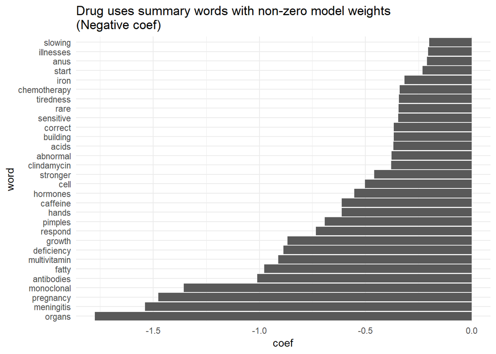

```r
### plots
by_brand_model_coef %>%
  arrange(coef) %>%
  head(30) %>%
  mutate(word = fct_reorder(word, coef)) %>%
  ggplot(aes(word, coef)) +
  geom_col() +
  coord_flip() +
  ggtitle("Drug uses summary words with non-zero model weights\n(Negative coef)")
```

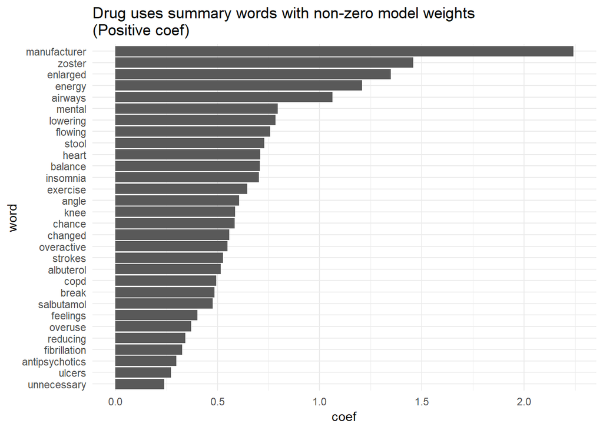

```r
by_brand_model_coef %>%
  filter(word != "(Intercept)") %>%
  arrange(desc(coef)) %>%
  head(30) %>%
  mutate(word = fct_reorder(word, coef)) %>%
  ggplot(aes(word, coef)) +
  geom_col() +
  coord_flip() +
  ggtitle("Drug uses summary words with non-zero model weights\n(Positive coef)")
```

```r
drug_token_filt %>%
  filter(word == "knee") %>%
  arrange(generic_name)
```

```
## # A tibble: 14 x 4
##    brand_name            generic_name          drug_num word
##    <chr>                 <chr>                    <int> <chr>
##  1 eliquis               apixaban                   760 knee
##  2 colchicine            colchicine                 514 knee
##  3 colcrys               colchicine                 515 knee
##  4 mitigare              colchicine                1501 knee
##  5 pennsaid              diclofenac sodium         1793 knee
##  6 enoxaparin sodium     enoxaparin sodium          784 knee
##  7 lovenox               enoxaparin sodium         1358 knee
##  8 arixtra               fondaparinux sodium        166 knee
##  9 fondaparinux sodium   fondaparinux sodium        948 knee
## 10 probenecid-colchicine probenecid/colchicine     1917 knee
## 11 xarelto               rivaroxaban               2518 knee
## 12 coumadin              warfarin sodium            557 knee
## 13 jantoven              warfarin sodium           1179 knee
## 14 warfarin sodium       warfarin sodium           2508 knee
```

```r
# this is a variety of different drugs - anti-inflammatory, anti-coagulants, blood thinners
# some make reference to preventing adverse events post-surgery (knee replacement), others treat arthritis
# zoster is shingles - skin condition common in older people
```

For drugs in this dataset, the `generic_name` corresponds to the active ingredient(s) that are responsible for the action of the drug. It’s possible that for some drugs with several brand names, the total claims count is being diluted across the different drugs.

Would the drug use words that are strongly associated with claim count change if the number of total claims was summarized differently?

```r
generic_token <- drug_token_filt %>%
  # discard brand name and will renumber drug again because count will go down
  select(-c(brand_name, drug_num)) %>%
  distinct() %>%
  arrange(generic_name) %>%
  inner_join(
    # new numbering based on generic name only (old one associated with brand/generic name combo)
    drug_token_filt %>%
      select(generic_name) %>%
      distinct() %>%
      arrange(generic_name) %>%
      mutate(drug_num = row_number()),
    by = "generic_name"
  )
# result:
generic_token
```

```
## # A tibble: 41,654 x 3
##    generic_name          word        drug_num
##    <chr>                 <chr>          <int>
##  1 0.9 % sodium chloride solution           1
##  2 0.9 % sodium chloride water              1
##  3 0.9 % sodium chloride salt               1
##  4 0.9 % sodium chloride sodium             1
##  5 0.9 % sodium chloride body               1
##  6 0.9 % sodium chloride mixed              1
##  7 0.9 % sodium chloride medications        1
##  8 0.9 % sodium chloride injection          1
##  9 0.9 % sodium chloride vein               1
## 10 abacavir sulfate      drug               2
## # ... with 41,644 more rows
```

```r
generic_claims_summ <- claims_summ %>%
  group_by(generic_name) %>%
  summarise(generic_claim = sum(sum_claims)) %>%
  ungroup() %>%
  inner_join(
    # merge with new drug num to keep key the same
    generic_token %>%
      select(generic_name, drug_num) %>%
      distinct(),
    by = "generic_name"
    ) %>%
  mutate(generic_claim_log = log2(generic_claim))
# result:
generic_claims_summ
```

```
## # A tibble: 1,450 x 4
##    generic_name                   generic_claim drug_num generic_claim_log
##    <chr>                                  <dbl>    <int>             <dbl>
##  1 0.9 % sodium chloride                 967272        1              19.9
##  2 abacavir sulfate                      340892        2              18.4
##  3 abacavir sulfate/lamivudine           758812        3              19.5
##  4 abacavir/dolutegravir/lamivudi        525268        4              19.0
##  5 abacavir/lamivudine/zidovudine         73843        5              16.2
##  6 abatacept                             180531        6              17.5
##  7 abatacept/maltose                      35916        7              15.1
##  8 abiraterone acetate                   460701        8              18.8
##  9 abobotulinumtoxina                      1320        9              10.4
## 10 acamprosate calcium                   112882       10              16.8
## # ... with 1,440 more rows
```

```r
# new sparse matrix and outcome
generic_token_mat <- generic_token %>%
  cast_sparse(drug_num, word)
dim(generic_token_mat)
```

```
## [1] 1450 1142
```

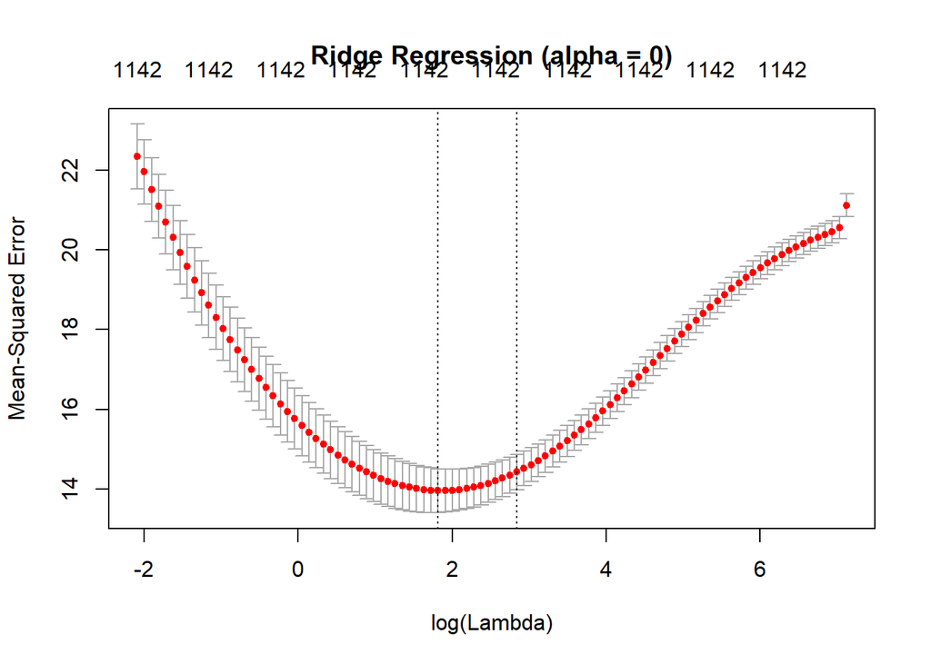

```r
# note: fewer rows than the previous set
generic_claims_mat <- as.matrix(generic_claims_summ$generic_claim_log)

by_generic_models <- a_param %>%
  map(function(x) cv.glmnet(generic_token_mat, generic_claims_mat, alpha = x, family = "gaussian"))
# mean-squared error vs. lambda plots:
plot(by_generic_models[[1]], main = "Ridge Regression (alpha = 0)")
```

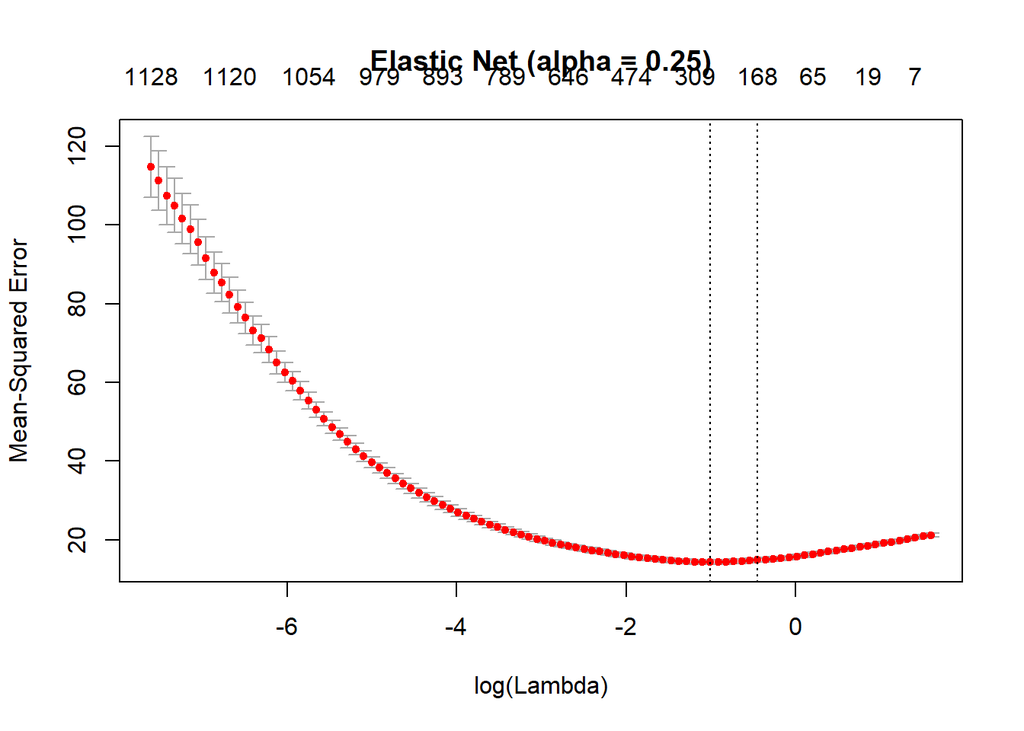

```r
plot(by_generic_models[[2]], main = "Elastic Net (alpha = 0.25)")
```

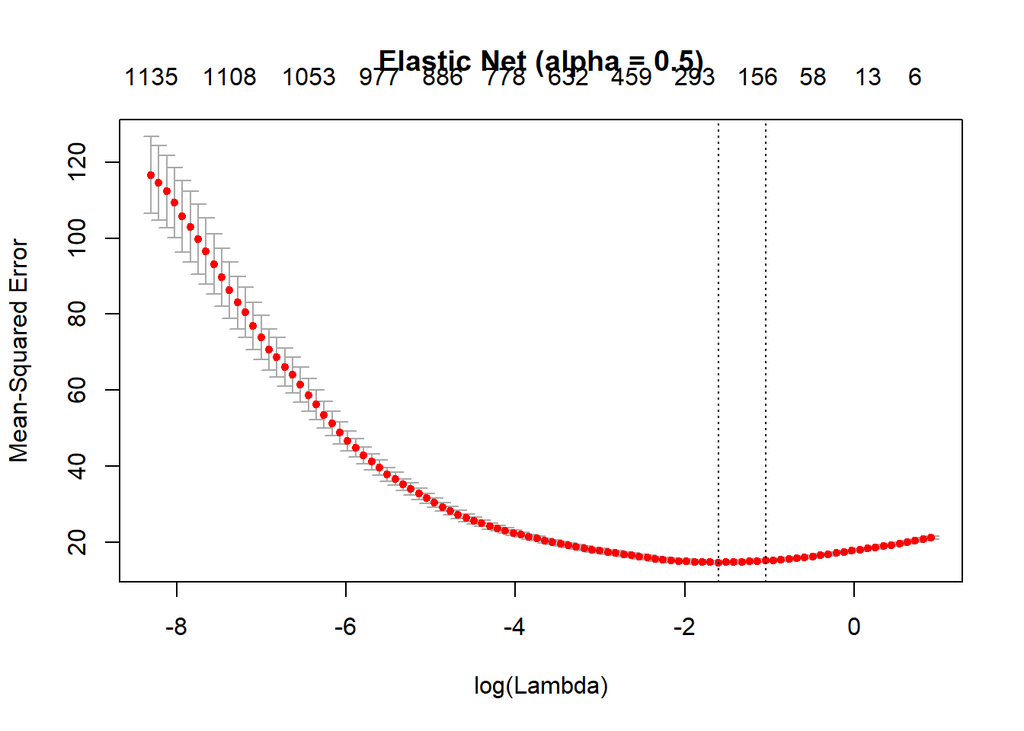

```r
plot(by_generic_models[[3]], main = "Elastic Net (alpha = 0.5)")
```

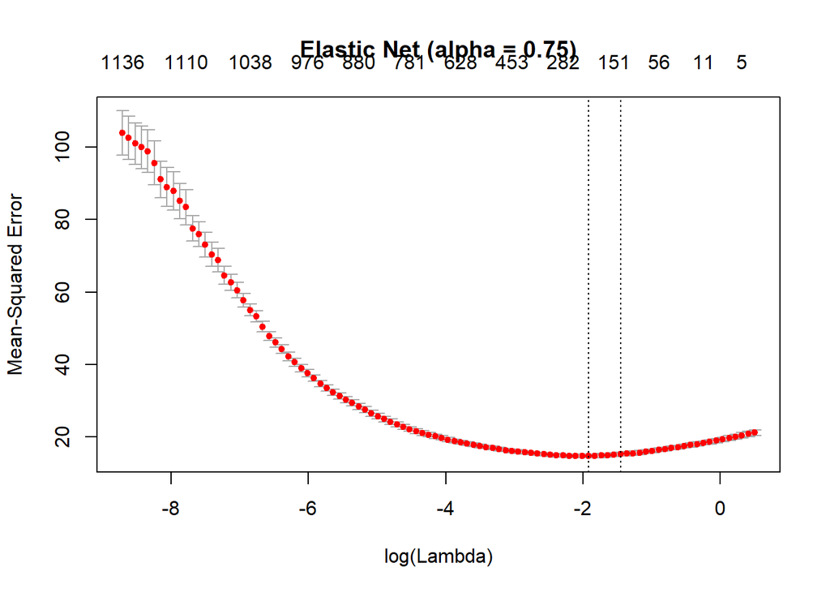

```r
plot(by_generic_models[[4]], main = "Elastic Net (alpha = 0.75)")
```

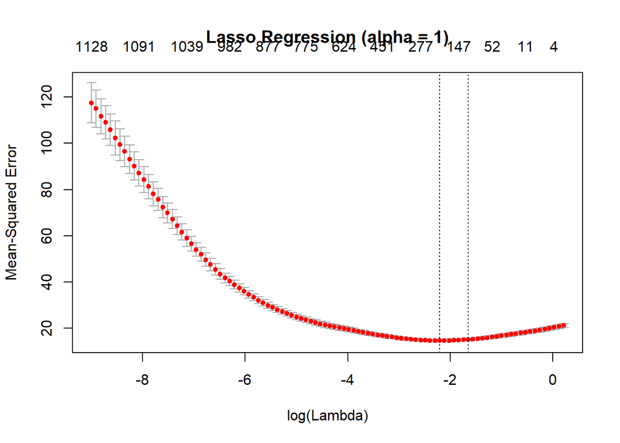

```r
plot(by_generic_models[[5]], main = "Lasso Regression (alpha = 1)")
```

```r
# lambda parameter optimization
by_generic_lambda_min <- map_dbl(by_generic_models, `[[`, "lambda.min")
by_generic_lambda_1se <- map_dbl(by_generic_models, `[[`, "lambda.1se")
# result:
by_generic_lambda_min
```

```
## [1] 6.1573926 0.3657413 0.2007003 0.1468456 0.1101342
```

```r
by_generic_lambda_1se
```

```
## [1] 17.1333106  0.6391433  0.3507295  0.2338197  0.1924626
```

```r
by_generic_models_tidy <- map(by_generic_models, function(x) tidy(x))
# mse for alpha = 0
by_generic_models_tidy[[1]] %>%
  filter(lambda == by_generic_lambda_1se[1])
```

```
## # A tibble: 1 x 6
##   lambda estimate std.error conf.low conf.high nzero
##    <dbl>    <dbl>     <dbl>    <dbl>     <dbl> <int>
## 1   17.1     14.4     0.438     14.0      14.9  1142
```

```r
# mse for alpha = 0.25
by_generic_models_tidy[[2]] %>%
  filter(lambda == by_generic_lambda_1se[2])
```

```
## # A tibble: 1 x 6
##   lambda estimate std.error conf.low conf.high nzero
##    <dbl>    <dbl>     <dbl>    <dbl>     <dbl> <int>
## 1  0.639     14.8     0.546     14.3      15.4   168
```

```r
# mse for alpha = 0.5
by_generic_models_tidy[[3]] %>%
  filter(lambda == by_generic_lambda_1se[3])
```

```
## # A tibble: 1 x 6
##   lambda estimate std.error conf.low conf.high nzero
##    <dbl>    <dbl>     <dbl>    <dbl>     <dbl> <int>
## 1  0.351     15.2     0.432     14.7      15.6   133
```

```r
# mse for alpha = 0.75
by_generic_models_tidy[[4]] %>%
  filter(lambda == by_generic_lambda_1se[4])
```

```
## # A tibble: 1 x 6
##   lambda estimate std.error conf.low conf.high nzero
##    <dbl>    <dbl>     <dbl>    <dbl>     <dbl> <int>
## 1  0.234     15.2     0.547     14.7      15.8   132
```

```r
# mse for alpha = 1
by_generic_models_tidy[[5]] %>%
  filter(lambda == by_generic_lambda_1se[5])
```

```
## # A tibble: 1 x 6
##   lambda estimate std.error conf.low conf.high nzero
##    <dbl>    <dbl>     <dbl>    <dbl>     <dbl> <int>
## 1  0.192     15.1     0.643     14.5      15.8   107
```

```r
# overall MSE error is about the same as for the previous model
# the ridge variant has the lowest error, but difficult to interpret, pick alpha = 0.25 variant
by_generic_fin_model <- by_generic_models[[2]]
by_generic_fin_model$lambda.1se
```

```
## [1] 0.6391433
```

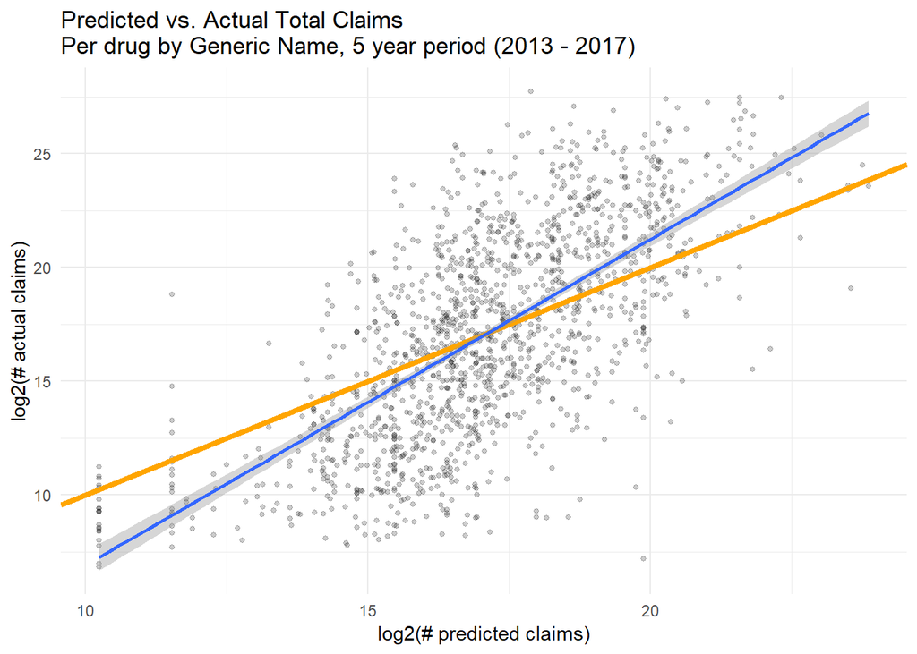

```r
# predictions - mse pretty high
generic_claims_summ$predictions <- predict(by_generic_fin_model, generic_token_mat)
generic_claims_summ %>%
  ggplot(aes(predictions, generic_claim_log)) +
  geom_point(size = 1, alpha = 0.2) +
  # unity line:
  geom_abline(intercept = 0, slope = 1, color = "orange", size = 1.5) +
  # acutal relationship:
  geom_smooth(method = "lm") +
  xlab("log2(# predicted claims)") +
  ylab("log2(# actual claims)") +
  ggtitle("Predicted vs. Actual Total Claims\nPer drug by Generic Name, 5 year period (2013 - 2017)")
```

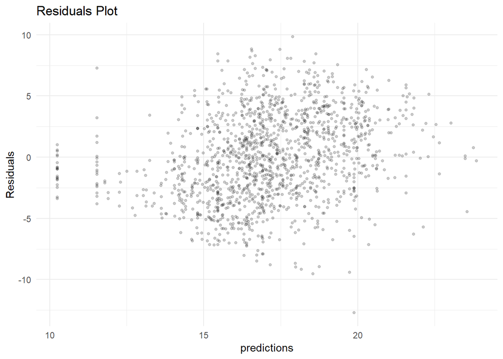

```r
generic_claims_summ <- generic_claims_summ %>%
  mutate(res = generic_claim_log - predictions)
generic_claims_summ %>%
  ggplot(aes(predictions, res)) +
  geom_point(size = 1, alpha = 0.2) +
  ylab("Residuals") +
  ggtitle("Residuals Plot")
```

```r
# root mean squared error:
sqrt(mean(generic_claims_summ$res^2))
```

```
## [1] 3.519856
```

```r
# vs sd:
sd(generic_claims_summ$generic_claim_log)
```

```
## [1] 4.602257
```

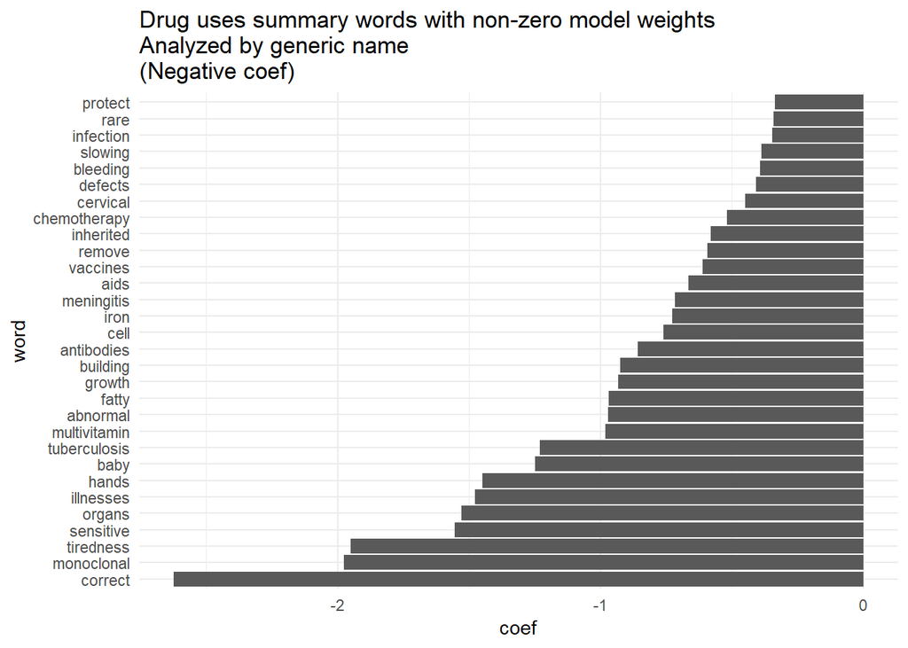

```r
# about the same fit quality as the previous model
# pull out words that had non-zero coefficients in the model
by_generic_model_coef <- coef(by_generic_fin_model, by_generic_fin_model$lambda.1se) %>%
  as.matrix() %>%
  as.data.frame() %>%
  rownames_to_column("word") %>%
  as_tibble() %>%
  rename("coef" = `1`) %>%
  filter(coef != 0) %>%
  mutate(abs_coef = abs(coef))
### plots
by_generic_model_coef %>%
  arrange(coef) %>%
  head(30) %>%
  mutate(word = fct_reorder(word, coef)) %>%
  ggplot(aes(word, coef)) +
  geom_col() +
  coord_flip() +
  ggtitle("Drug uses summary words with non-zero model weights\nAnalyzed by generic name\n(Negative coef)")
```

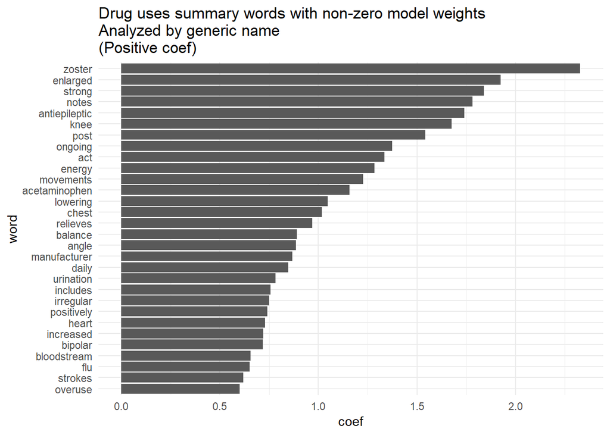

```r
by_generic_model_coef %>%
  filter(word != "(Intercept)") %>%
  arrange(desc(coef)) %>%
  head(30) %>%
  mutate(word = fct_reorder(word, coef)) %>%
  ggplot(aes(word, coef)) +
  geom_col() +
  coord_flip() +
  ggtitle("Drug uses summary words with non-zero model weights\nAnalyzed by generic name\n(Positive coef)")
```

```r
# which words are in both?
shared_model_words <- by_brand_model_coef %>%
  inner_join(by_generic_model_coef, by = "word", suffix = c("_brand", "_generic")) %>%
  filter(word != "(Intercept)")
shared_model_words
```

```
## # A tibble: 71 x 5
##    word         coef_brand abs_coef_brand coef_generic abs_coef_generic
##    <chr>             <dbl>          <dbl>        <dbl>            <dbl>
##  1 infection       -0.0143         0.0143       -0.347            0.347
##  2 growth          -0.867          0.867        -0.932            0.932
##  3 mental           0.795          0.795         0.188            0.188
##  4 balance          0.708          0.708         0.890            0.890
##  5 chemotherapy    -0.339          0.339        -0.518            0.518
##  6 slowing         -0.200          0.200        -0.388            0.388
##  7 start           -0.231          0.231        -0.142            0.142
##  8 reduce           0.0453         0.0453        0.571            0.571
##  9 exercise         0.645          0.645         0.406            0.406
## 10 heart            0.710          0.710         0.730            0.730
## # ... with 61 more rows
```

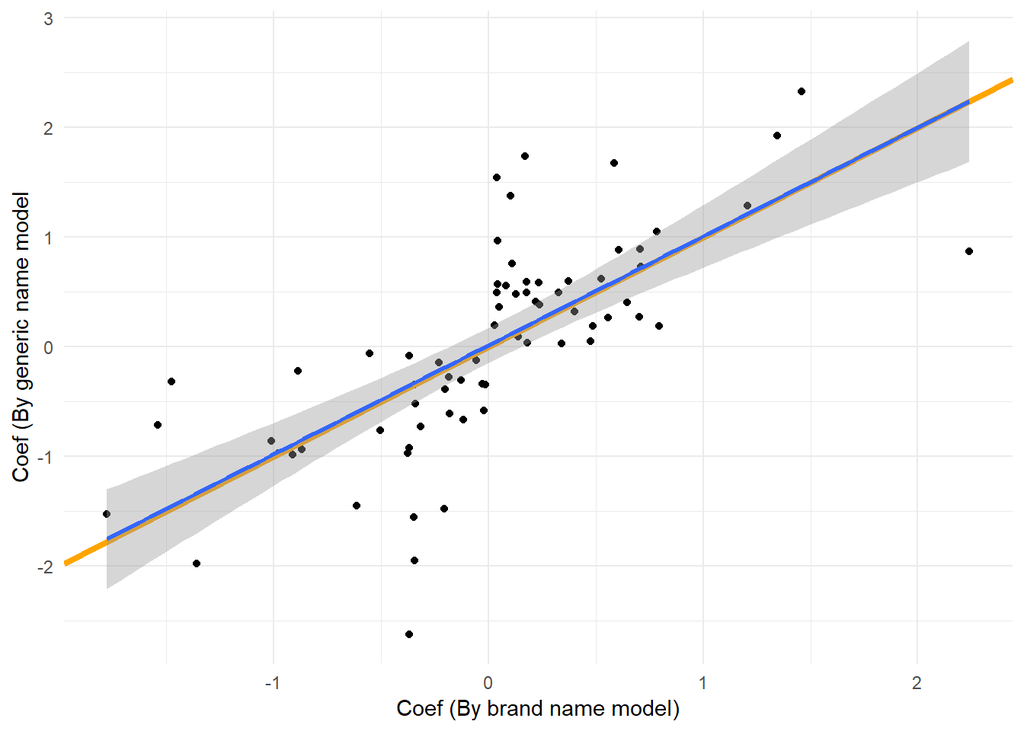

```r
shared_model_words %>%
  ggplot(aes(coef_brand, coef_generic)) +
  geom_point() +
  xlab("Coef (By brand name model)") +
  ylab("Coef (By generic name model") +
  # unity line:
  geom_abline(intercept = 0, slope = 1, color = "orange", size = 1.5) +
  # acutal relationship:
  geom_smooth(method = "lm")
```

In general, if a coefficient for a particular word is negative in one model, it is negative in the other (and vice versa), by the magnitude of the coefficient can vary.